# Project: DATASET INVESTIGATION - [GUN PERMIT DATA ANALYSIS]

## US-CENSUS_DATA

```python
US_censusdata.info()
US_censusdata.head(2)
```

```
<class 'pandas.core.frame.DataFrame'>
RangeIndex: 85 entries, 0 to 84
Data columns (total 52 columns):
 #   Column          Non-Null Count  Dtype
---  ------          --------------  -----
 0   Fact            80 non-null     object
 1   Fact Note       28 non-null     object
 2   Alabama         65 non-null     object
 3   Alaska          65 non-null     object
 4   Arizona         65 non-null     object
 5   Arkansas        65 non-null     object
 6   California      65 non-null     object
 7   Colorado        65 non-null     object
 8   Connecticut     65 non-null     object
 9   Delaware        65 non-null     object
```

[output cut: 44 more lines]

|  | Fact | Fact Note | Alabama | Alaska | Arizona | Arkansas | California | Colorado | Connecticut | Delaware | ... | South Dakota | Tennessee | Texas | Utah | Vermont | Virginia | Washington | West Virginia | Wisconsin | Wyoming |
| --- | --- | --- | --- | --- | --- | --- | --- | --- | --- | --- | --- | --- | --- | --- | --- | --- | --- | --- | --- | --- | --- |
| 0 | Population estimates, July 1, 2016, (V2016) | NaN | 4863300 | 741894 | 6931071 | 2988248 | 39250017 | 5540545 | 3576452 | 952065 | ... | 865454 | 6651194 | 27862596 | 3051217 | 624594 | 8411808 | 7288000 | 1831102 | 5778708 | 585501 |
| 1 | Population estimates base, April 1, 2010, (V2... | NaN | 4780131 | 710249 | 6392301 | 2916025 | 37254522 | 5029324 | 3574114 | 897936 | ... | 814195 | 6346298 | 25146100 | 2763888 | 625741 | 8001041 | 6724545 | 1853011 | 5687289 | 563767 |

2 rows × 52 columns

```python
#Listing all columns of df_permit_check
US_censusdata.columns
```

```
Index(['Fact', 'Fact Note', 'Alabama', 'Alaska', 'Arizona', 'Arkansas',
       'California', 'Colorado', 'Connecticut', 'Delaware', 'Florida',
       'Georgia', 'Hawaii', 'Idaho', 'Illinois', 'Indiana', 'Iowa', 'Kansas',
       'Kentucky', 'Louisiana', 'Maine', 'Maryland', 'Massachusetts',
       'Michigan', 'Minnesota', 'Mississippi', 'Missouri', 'Montana',
       'Nebraska', 'Nevada', 'New Hampshire', 'New Jersey', 'New Mexico',
       'New York', 'North Carolina', 'North Dakota', 'Ohio', 'Oklahoma',
       'Oregon', 'Pennsylvania', 'Rhode Island', 'South Carolina',
       'South Dakota', 'Tennessee', 'Texas', 'Utah', 'Vermont', 'Virginia',
       'Washington', 'West Virginia', 'Wisconsin', 'Wyoming'],
      dtype='object')
```

```python
col_names2 = ['Alabama', 'Alaska','Arizona','Arkansas',
       'California', 'Colorado','Connecticut','Delaware','Florida',
       'Georgia','Hawaii','Idaho','Illinois','Indiana', 'Iowa','Kansas',
       'Kentucky','Louisiana','Maine', 'Maryland','Massachusetts',
       'Michigan','Minnesota','Mississippi', 'Missouri', 'Montana',
       'Nebraska', 'Nevada','New Hampshire', 'New Jersey', 'New Mexico',
       'New York','North Carolina', 'North Dakota', 'Ohio', 'Oklahoma',
       'Oregon','Pennsylvania', 'Rhode Island','South Carolina',
       'South Dakota','Tennessee', 'Texas', 'Utah','Vermont','Virginia',
       'Washington','West Virginia','Wisconsin','Wyoming']
```

```python
# Changing all NaN values to 0
for col in col_names2:
    # Changing all NaN values to 0
    US_censusdata[col] = US_censusdata[col].replace(np.NaN, 0)
```

```python
#Checking for duplicated copies
US_censusdata[US_censusdata.duplicated(keep=False)]
```

|  | Fact | Fact Note | Alabama | Alaska | Arizona | Arkansas | California | Colorado | Connecticut | Delaware | ... | South Dakota | Tennessee | Texas | Utah | Vermont | Virginia | Washington | West Virginia | Wisconsin | Wyoming |
| --- | --- | --- | --- | --- | --- | --- | --- | --- | --- | --- | --- | --- | --- | --- | --- | --- | --- | --- | --- | --- | --- |
| 65 | NaN | NaN | 0 | 0 | 0 | 0 | 0 | 0 | 0 | 0 | ... | 0 | 0 | 0 | 0 | 0 | 0 | 0 | 0 | 0 | 0 |
| 67 | NaN | NaN | 0 | 0 | 0 | 0 | 0 | 0 | 0 | 0 | ... | 0 | 0 | 0 | 0 | 0 | 0 | 0 | 0 | 0 | 0 |
| 70 | NaN | NaN | 0 | 0 | 0 | 0 | 0 | 0 | 0 | 0 | ... | 0 | 0 | 0 | 0 | 0 | 0 | 0 | 0 | 0 | 0 |
| 75 | NaN | NaN | 0 | 0 | 0 | 0 | 0 | 0 | 0 | 0 | ... | 0 | 0 | 0 | 0 | 0 | 0 | 0 | 0 | 0 | 0 |

4 rows × 52 columns

```python
#remove all duplicate rows
US_censusdata.drop_duplicates(keep=False,inplace=True)

#rechecking for duplicated copies
US_censusdata.duplicated().sum()
```

```
0
```

```python
US_censusdata.info()
```

```
<class 'pandas.core.frame.DataFrame'>
Int64Index: 81 entries, 0 to 84
Data columns (total 52 columns):
 #   Column          Non-Null Count  Dtype
---  ------          --------------  -----
 0   Fact            80 non-null     object
 1   Fact Note       28 non-null     object
 2   Alabama         81 non-null     object
 3   Alaska          81 non-null     object
 4   Arizona         81 non-null     object
 5   Arkansas        81 non-null     object
 6   California      81 non-null     object
 7   Colorado        81 non-null     object
 8   Connecticut     81 non-null     object
 9   Delaware        81 non-null     object
```

[output cut: 44 more lines]

### Data Cleaning

> From the above two data, it is discover that the df_permit_check data is center on type of guns and population in each state. Extensive details or features of the population in each state is not provided while the US_censusdata provide various features like house, employment, age_cateorgy etc related to the population cenus from 2010 to 2016.

We only concentrate on vital information that are relevant to the two data or that can help us to provide solutions to the research questions that are previously stated above. Step by step cleaning will be perform to finetune the dataset

```python
#it is observed that US-census data has 50 state and the Gun-permit data has 55 state.Hence we delete state not present in the census data
df_permit_check.state .unique()
US_censusdata.columns

#kRemovinng the last 5 states not cover in both dataset


df_permit_check= df_permit_check[df_permit_check['state'] != 'Guam']
df_permit_check= df_permit_check[df_permit_check['state'] != 'District of Columbia']
df_permit_check= df_permit_check[df_permit_check['state'] != 'Mariana Islands']
df_permit_check= df_permit_check[df_permit_check['state'] != 'Puerto Rico']
df_permit_check= df_permit_check[df_permit_check['state'] != 'Virgin Islands']

#reconfirm the unique state present in df_permit_check dataframe
df_permit_check.state.nunique()
```

```
50
```

```python
#df_permit_check data  rows for each state for 2010 and 2016.
#Source: https://sparkbyexamples.com/pandas/pandas-select-dataframe-rows-between-two-dates/#:~:text=In%20order%20to%20select%20rows,the%20range%20using%20the%20DataFrame


df_permit_check2016 = df_permit_check.loc[(df_permit_check["month"] >= "2016-01-01") & (df_permit_check["month"] <= "2016-12-01")]

df_permit_check2010 = df_permit_check.loc[(df_permit_check["month"] >= "2010-01-01") & (df_permit_check["month"] <= "2010-12-01")]


df_permit_check2016.head()
```

|  | month | state | permit | permit_recheck | handgun | long_gun | other | multiple | admin | prepawn_handgun | ... | returned_other | rentals_handgun | rentals_long_gun | private_sale_handgun | private_sale_long_gun | private_sale_other | return_to_seller_handgun | return_to_seller_long_gun | return_to_seller_other | totals |
| --- | --- | --- | --- | --- | --- | --- | --- | --- | --- | --- | --- | --- | --- | --- | --- | --- | --- | --- | --- | --- | --- |
| 495 | 2016-12-01 | Alabama | 26996 | 0 | 13733 | 17519 | 376 | 533 | 0 | 10 | ... | 0 | 0 | 0 | 2 | 2 | 1 | 0 | 0 | 0 | 62014 |
| 496 | 2016-12-01 | Alaska | 254 | 0 | 4087 | 3698 | 243 | 191 | 0 | 3 | ... | 0 | 0 | 0 | 0 | 0 | 0 | 0 | 0 | 0 | 8786 |
| 497 | 2016-12-01 | Arizona | 8900 | 121 | 18024 | 13785 | 1180 | 703 | 0 | 10 | ... | 0 | 0 | 0 | 2 | 2 | 0 | 0 | 0 | 0 | 44887 |
| 498 | 2016-12-01 | Arkansas | 3294 | 692 | 9192 | 13433 | 277 | 385 | 37 | 4 | ... | 0 | 0 | 0 | 2 | 7 | 0 | 0 | 0 | 0 | 29926 |
| 499 | 2016-12-01 | California | 61808 | 0 | 63649 | 93224 | 77929 | 0 | 0 | 0 | ... | 0 | 0 | 0 | 0 | 0 | 0 | 0 | 0 | 0 | 298161 |

5 rows × 27 columns

```python
#Pulling out the most necessary columns needed. These columns are Month, state and total of permit of all type of firearms

df_permit_check2016A = df_permit_check2016[['month','state', 'totals']]

df_permit_check2010A = df_permit_check2010[['month','state', 'totals']]


df_permit_check2016A.head()
df_permit_check2010A.head()
```

|  | month | state | totals |
| --- | --- | --- | --- |
| 4455 | 2010-12-01 | Alabama | 43266 |
| 4456 | 2010-12-01 | Alaska | 7036 |
| 4457 | 2010-12-01 | Arizona | 23942 |
| 4458 | 2010-12-01 | Arkansas | 23821 |
| 4459 | 2010-12-01 | California | 81522 |

# US_CENSUSDATA

```python
#Fact_Note column  is drop to allow know the number of column relevant to our analysis

US_censusdata.drop(['Fact Note'], axis=1, inplace=True)
US_censusdata.sample(3)
```

|  | Fact | Alabama | Alaska | Arizona | Arkansas | California | Colorado | Connecticut | Delaware | Florida | ... | South Dakota | Tennessee | Texas | Utah | Vermont | Virginia | Washington | West Virginia | Wisconsin | Wyoming |
| --- | --- | --- | --- | --- | --- | --- | --- | --- | --- | --- | --- | --- | --- | --- | --- | --- | --- | --- | --- | --- | --- |
| 37 | Persons without health insurance, under age 6... | 0 | 0 | 0 | 0 | 0 | 0 | 0 | 0 | 0 | ... | 0 | 0 | 0 | 0 | 0 | 0 | 0 | 0 | 0 | 0 |
| 61 | Nonveteran-owned firms, 2012 | 316984 | 56091 | 427582 | 192988 | 3176341 | 469524 | 281182 | 60318 | 1846686 | ... | 66219 | 469392 | 2057218 | 219807 | 63317 | 548439 | 461401 | 94960 | 370755 | 51353 |
| 73 | (b) | 0 | 0 | 0 | 0 | 0 | 0 | 0 | 0 | 0 | ... | 0 | 0 | 0 | 0 | 0 | 0 | 0 | 0 | 0 | 0 |

3 rows × 51 columns

```python
# US_censusdata

# retrieving important rows in the US-Census data frame. Population census 2016 and population Estimates 2016 April 1 and July 1 respectively
pop_data= US_censusdata.loc[(US_censusdata['Fact'] == 'Population, Census, April 1, 2010') | (US_censusdata['Fact'] == 'Population estimates base, April 1, 2010,  (V2016)') | (US_censusdata['Fact'] == 'Population estimates, July 1, 2016,  (V2016)')]

pop_data.head()
```

|  | Fact | Alabama | Alaska | Arizona | Arkansas | California | Colorado | Connecticut | Delaware | Florida | ... | South Dakota | Tennessee | Texas | Utah | Vermont | Virginia | Washington | West Virginia | Wisconsin | Wyoming |
| --- | --- | --- | --- | --- | --- | --- | --- | --- | --- | --- | --- | --- | --- | --- | --- | --- | --- | --- | --- | --- | --- |
| 0 | Population estimates, July 1, 2016, (V2016) | 4863300 | 741894 | 6931071 | 2988248 | 39250017 | 5540545 | 3576452 | 952065 | 20612439 | ... | 865454 | 6651194 | 27862596 | 3051217 | 624594 | 8411808 | 7288000 | 1831102 | 5778708 | 585501 |
| 1 | Population estimates base, April 1, 2010, (V2... | 4780131 | 710249 | 6392301 | 2916025 | 37254522 | 5029324 | 3574114 | 897936 | 18804592 | ... | 814195 | 6346298 | 25146100 | 2763888 | 625741 | 8001041 | 6724545 | 1853011 | 5687289 | 563767 |
| 3 | Population, Census, April 1, 2010 | 4779736 | 710231 | 6392017 | 2915918 | 37253956 | 5029196 | 3574097 | 897934 | 18801310 | ... | 814180 | 6346105 | 25145561 | 2763885 | 625741 | 8001024 | 6724540 | 1852994 | 5686986 | 563626 |

3 rows × 51 columns

```python
#transpose data to enable the column(States) in Us-censusdata look like the permit_check
pop_data_df = pop_data.transpose()

pop_data_df.head()
```

|  | 0 | 1 | 3 |
| --- | --- | --- | --- |
| Fact | Population estimates, July 1, 2016, (V2016) | Population estimates base, April 1, 2010, (V2... | Population, Census, April 1, 2010 |
| Alabama | 4863300 | 4780131 | 4779736 |
| Alaska | 741894 | 710249 | 710231 |
| Arizona | 6931071 | 6392301 | 6392017 |
| Arkansas | 2988248 | 2916025 | 2915918 |

```python
pop_data_df.info()
```

```
<class 'pandas.core.frame.DataFrame'>
Index: 51 entries, Fact to Wyoming
Data columns (total 3 columns):
 #   Column  Non-Null Count  Dtype
---  ------  --------------  -----
 0   0       51 non-null     object
 1   1       51 non-null     object
 2   3       51 non-null     object
dtypes: object(3)
memory usage: 4.1+ KB
```

```python
#reseting index.
#source: https://www.geeksforgeeks.org/how-to-change-index-values-in-pandas/
pop_data_df2 = pop_data_df.reset_index(drop=True)
pop_data_df2.info()
```

```
<class 'pandas.core.frame.DataFrame'>
RangeIndex: 51 entries, 0 to 50
Data columns (total 3 columns):
 #   Column  Non-Null Count  Dtype
---  ------  --------------  -----
 0   0       51 non-null     object
 1   1       51 non-null     object
 2   3       51 non-null     object
dtypes: object(3)
memory usage: 1.3+ KB
```

```python
#adding the state list to the dataset
state =(['Fact', 'Alabama', 'Alaska', 'Arizona', 'Arkansas', 'California',
       'Colorado', 'Connecticut', 'Delaware', 'Florida', 'Georgia', 'Hawaii',
       'Idaho', 'Illinois', 'Indiana', 'Iowa', 'Kansas', 'Kentucky',
       'Louisiana', 'Maine', 'Maryland', 'Massachusetts', 'Michigan',
       'Minnesota', 'Mississippi', 'Missouri', 'Montana', 'Nebraska', 'Nevada',
       'New Hampshire', 'New Jersey', 'New Mexico', 'New York',
       'North Carolina', 'North Dakota', 'Ohio', 'Oklahoma', 'Oregon',
       'Pennsylvania', 'Rhode Island', 'South Carolina', 'South Dakota',
       'Tennessee', 'Texas', 'Utah', 'Vermont', 'Virginia', 'Washington',
       'West Virginia', 'Wisconsin', 'Wyoming'])

#create new index
Column_to_make_index = np.arange(0,51)
Column_to_make_index
pop_data_df2['Column_to_make_index']= Column_to_make_index
pop_data_df2['states']= state

pop_data_df2.head()
```

|  | 0 | 1 | 3 | Column_to_make_index | states |
| --- | --- | --- | --- | --- | --- |
| 0 | Population estimates, July 1, 2016, (V2016) | Population estimates base, April 1, 2010, (V2... | Population, Census, April 1, 2010 | 0 | Fact |
| 1 | 4863300 | 4780131 | 4779736 | 1 | Alabama |
| 2 | 741894 | 710249 | 710231 | 2 | Alaska |
| 3 | 6931071 | 6392301 | 6392017 | 3 | Arizona |
| 4 | 2988248 | 2916025 | 2915918 | 4 | Arkansas |

```python
UsAdj_pop = pop_data_df2.set_index('Column_to_make_index')
```

```python
list(UsAdj_pop.columns)
```

```
[0, 1, 3, 'states']
```

```python
#renaming column
#source: https://www.geeksforgeeks.org/how-to-get-column-names-in-pandas-dataframe/
UsAdj_pop.columns.values[0:3] =["PopJuly2016", "PopApril2016", "CensusApril2010"]
UsAdj_pop.head()
```

| Column_to_make_index | PopJuly2016 | PopApril2016 | CensusApril2010 | states |
| --- | --- | --- | --- | --- |
| 0 | Population estimates, July 1, 2016, (V2016) | Population estimates base, April 1, 2010, (V2... | Population, Census, April 1, 2010 | Fact |
| 1 | 4863300 | 4780131 | 4779736 | Alabama |
| 2 | 741894 | 710249 | 710231 | Alaska |
| 3 | 6931071 | 6392301 | 6392017 | Arizona |
| 4 | 2988248 | 2916025 | 2915918 | Arkansas |

```python
#delete the first row that is not relevant
UsAdj_pop =UsAdj_pop.iloc[1:]

UsAdj_pop.info()
```

```
<class 'pandas.core.frame.DataFrame'>
Int64Index: 50 entries, 1 to 50
Data columns (total 4 columns):
 #   Column           Non-Null Count  Dtype
---  ------           --------------  -----
 0   PopJuly2016      50 non-null     object
 1   PopApril2016     50 non-null     object
 2   CensusApril2010  50 non-null     object
 3   states           50 non-null     object
dtypes: object(4)
memory usage: 2.0+ KB
```

```python
#convert object to int
UsAdj_pop[['PopJuly2016', 'PopApril2016','CensusApril2010' ]] = UsAdj_pop[['PopJuly2016', 'PopApril2016', 'CensusApril2010']].astype(int)
```

## Exploratory Data Analysis

> **Tip**: Now that you've trimmed and cleaned your data, you're ready to move on to exploration. **Compute statistics** and **create visualizations** with the goal of addressing the research questions that you posed in the Introduction section. You should compute the relevant statistics throughout the analysis when an inference is made about the data. Note that at least two or more kinds of plots should be created as part of the exploration, and you must compare and show trends in the varied visualizations.
> - Investigate the stated question(s) from multiple angles. It is recommended that you be systematic with your approach. Look at one variable at a time, and then follow it up by looking at relationships between variables. You should explore at least three variables in relation to the primary question. This can be an exploratory relationship between three variables of interest, or looking at how two independent variables relate to a single dependent variable of interest. Lastly, you should perform both single-variable (1d) and multiple-variable (2d) explorations.

# Significant of research question(Distribution of Firarms per states between 2010 -2016)

This findings enable us to know the distribution mean, standard deviation, highest permit of firearms per state etc

It is discover that Kentucky state has the highest demand of firearms between 2010-2016

```python
#Extracting dataset between 2010-01-01 & 2016-01-01
df_permit_check20102016 = df_permit_check.loc[(df_permit_check["month"] >= "2010-01-01") & (df_permit_check["month"] <= "2016-12-01")]

#df_permit_check20102016
```

```python
#Identity the total firearms per state between 2010-2016
df_permit_check20102016A = df_permit_check20102016[['state', 'totals']]
```

```python
#grouping and renaming
re_grouped= df_permit_check20102016A.groupby('state').agg({'totals': ['sum', 'min', 'max', 'std']})
re_grouped.columns = ['sum','min', 'max', 'std']
re_grouped = re_grouped.reset_index(drop=False)
re_grouped.head()

#Source:https://jamesrledoux.com/code/group-by-aggregate-pandas
```

|  | state | sum | min | max | std |
| --- | --- | --- | --- | --- | --- |
| 0 | Alabama | 3615706 | 18752 | 120914 | 18020.535574 |
| 1 | Alaska | 575745 | 3821 | 12438 | 1578.633266 |
| 2 | Arizona | 2218619 | 13846 | 48795 | 7351.177332 |
| 3 | Arkansas | 1681247 | 11251 | 38830 | 5642.384223 |
| 4 | California | 9835860 | 60530 | 298161 | 48429.514946 |

```python
#state with the highest total number between 2010 -2016
re_grouped[re_grouped['sum'] == re_grouped['sum'].max()]
```

|  | state | sum | min | max | std |
| --- | --- | --- | --- | --- | --- |
| 16 | Kentucky | 18221502 | 25271 | 397059 | 81602.935409 |

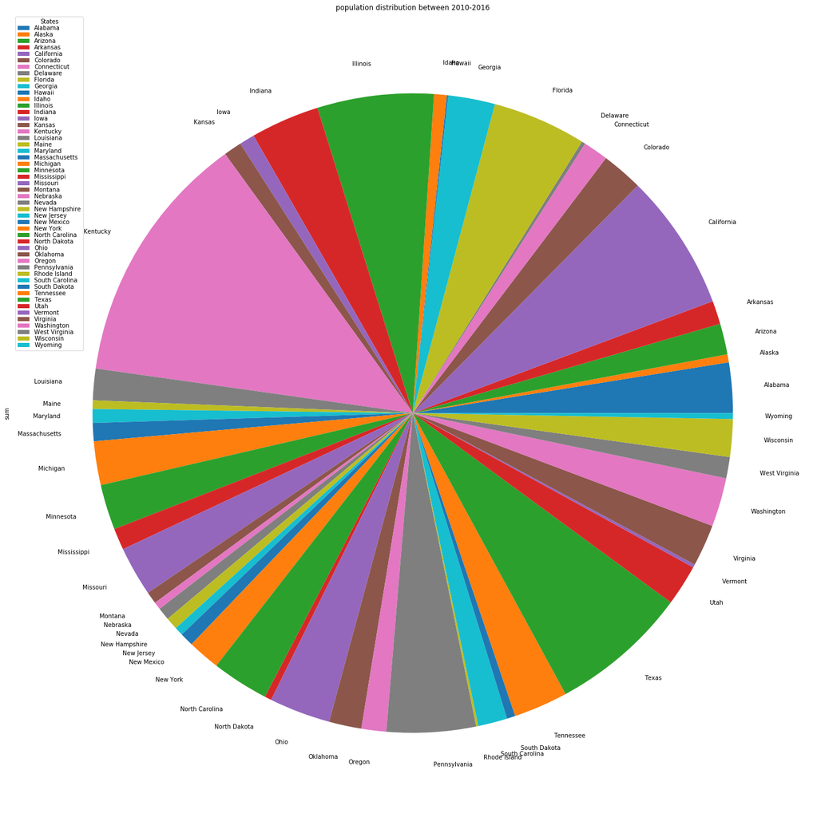

```python
# Plotting the pie chart for above 50 states between 2010-2016
re_grouped.groupby(['state']).sum().plot(kind='pie', y='sum', rot= 1090, title="population distribution between 2010-2016", figsize=(25,25))

plt.legend(loc='upper left', title='States', labelspacing=0.1)
```

# Significant of research question (#What census data is most associated with high gun per capital?)

```python
#At each state level in 2010
#compare 2010 and 2016



totalpermit_per_state2010 = df_permit_check2010.groupby('state').sum()
totalpermit_per_state2010 = totalpermit_per_state2010.reset_index(drop=True)
totalpermit_per_state2010

totalpermit_per_state2016 = df_permit_check2016.groupby('state').sum()
totalpermit_per_state2016 = totalpermit_per_state2016.reset_index(drop=True)
totalpermit_per_state2016.head()
```

|  | permit | permit_recheck | handgun | long_gun | other | multiple | admin | prepawn_handgun | prepawn_long_gun | prepawn_other | ... | returned_other | rentals_handgun | rentals_long_gun | private_sale_handgun | private_sale_long_gun | private_sale_other | return_to_seller_handgun | return_to_seller_long_gun | return_to_seller_other | totals |
| --- | --- | --- | --- | --- | --- | --- | --- | --- | --- | --- | --- | --- | --- | --- | --- | --- | --- | --- | --- | --- | --- |
| 0 | 291039 | 0 | 153123 | 121963 | 6104 | 6545 | 5 | 111 | 114 | 2 | ... | 0 | 0 | 0 | 72 | 65 | 4 | 3 | 2 | 0 | 616947 |
| 1 | 3121 | 0 | 37491 | 36887 | 2889 | 2316 | 0 | 84 | 70 | 0 | ... | 0 | 0 | 0 | 39 | 66 | 1 | 2 | 3 | 0 | 87647 |
| 2 | 87771 | 5109 | 166784 | 108988 | 13122 | 7908 | 0 | 74 | 60 | 3 | ... | 1 | 0 | 0 | 76 | 56 | 11 | 11 | 11 | 1 | 416279 |
| 3 | 55456 | 7036 | 80244 | 82120 | 3059 | 4400 | 143 | 77 | 116 | 3 | ... | 0 | 0 | 0 | 72 | 64 | 6 | 7 | 4 | 1 | 266014 |
| 4 | 1036981 | 0 | 560355 | 554550 | 211707 | 0 | 0 | 0 | 0 | 0 | ... | 0 | 0 | 0 | 0 | 0 | 0 | 0 | 0 | 0 | 2377167 |

5 rows × 25 columns

```python
#adding the state list to the dataset
state =(['Alabama', 'Alaska', 'Arizona', 'Arkansas', 'California',
       'Colorado', 'Connecticut', 'Delaware', 'Florida', 'Georgia', 'Hawaii',
       'Idaho', 'Illinois', 'Indiana', 'Iowa', 'Kansas', 'Kentucky',
       'Louisiana', 'Maine', 'Maryland', 'Massachusetts', 'Michigan',
       'Minnesota', 'Mississippi', 'Missouri', 'Montana', 'Nebraska', 'Nevada',
       'New Hampshire', 'New Jersey', 'New Mexico', 'New York',
       'North Carolina', 'North Dakota', 'Ohio', 'Oklahoma', 'Oregon',
       'Pennsylvania', 'Rhode Island', 'South Carolina', 'South Dakota',
       'Tennessee', 'Texas', 'Utah', 'Vermont', 'Virginia', 'Washington',
       'West Virginia', 'Wisconsin', 'Wyoming'])

totalpermit_per_state2010['states']= state
per_state2010 = totalpermit_per_state2010
```